# 14-kdm6b-expression-subcluster-definition

Bicna Song

2026-08-20

This analysis addresses:

1. compare pseudobulk `Kdm6b` expression across treatments in all cells, T cells, and myeloid cells
2. visualize `Kdm6b` in the myeloid compartment
3. Define Kdm6b-high and Kdm6b-low myeloid subclusters.
4. Visualize `Kdm6b` in within the T cell compartment
5. Define Kdm6b-high and Kdm6b-low T cell subclusters.

## Setup

```r
suppressPackageStartupMessages({
  library(rprojroot)
  library(dplyr)
  library(Seurat)
  library(ggplot2)
  library(patchwork)
})

root_dir <- find_root(has_dir(".git"))
data_dir <- file.path(root_dir, "data", "v5")
analysis_dir <- file.path(root_dir, "analyses", "downstream-analyses")
results_dir <- file.path(analysis_dir, "results", "myeloid", "kdm6b")
plot_dir <- file.path(analysis_dir, "plots", "myeloid", "kdm6b")

dir.create(results_dir, recursive = TRUE, showWarnings = FALSE)
dir.create(plot_dir, recursive = TRUE, showWarnings = FALSE)

source(file.path(root_dir, "figures", "theme.R"))
source(file.path(analysis_dir, "util", "kdm6b_expression_helpers.R"))

set.seed(1234)
```

## Analysis parameters

```r
gene <- "Kdm6b"
compartment_levels <- c("All cells", "T cells", "Myeloid cells")

input_files <- list(
  all_cells = file.path(data_dir, "cart_annotated.rds"),
  t_cells = file.path(data_dir, "cart_tcell_subtypes.rds"),
  myeloid = file.path(data_dir, "cart_myeloid_subtypes.rds")
)
missing_input_files <- unlist(input_files)[!file.exists(unlist(input_files))]
if (length(missing_input_files) > 0) {
  stop("Missing input file(s): ", paste(missing_input_files, collapse = ", "))
}

condition_levels <- c(
  "41BB-L", "B7H3", "CD28-41BB", "CD8-41BB", "STOP", "tumor"
)

condition_colors <- c(
  "41BB-L" = "#1B9E77",
  "B7H3" = "#7570B3",
  "CD28-41BB" = "#E7298A",
  "CD8-41BB" = "#D95F02",
  "STOP" = "#BDBDBD",
  "tumor" = "#66A61E"
)

# Minimum cells required for a sample/subcluster expression profile.
min_cells_per_profile <- 20L

# Assign the most and least expressed quartiles to the high and low groups.
tail_fraction <- 0.25
```

## 1. Compare pseudobulk Kdm6b expression across treatment groups

Raw RNA counts are aggregated within each biological sample. DESeq2 size factors are estimated from the full pseudobulk transcriptome separately for each compartment. The plots show individual samples; no pooled cell-level test is used. Log2-transformed normalized counts are shown to compare treatment conditions within each compartment. Because normalization is performed separately, the y-axis magnitudes should not be compared across compartments.

### All cells

```r
all_obj <- readRDS(input_files$all_cells)

all_pseudobulk <- aggregate_kdm6b_by_sample(
  obj = all_obj,
  compartment = "All cells",
  condition_levels = condition_levels,
  gene = gene
)

rm(all_obj)
invisible(gc())
```

### T cells

```r
tcell_obj <- readRDS(input_files$t_cells)

tcell_pseudobulk <- aggregate_kdm6b_by_sample(
  obj = tcell_obj,
  compartment = "T cells",
  condition_levels = condition_levels,
  gene = gene
)
```

### Myeloid cells

```r
myeloid_obj <- readRDS(input_files$myeloid)

myeloid_pseudobulk <- aggregate_kdm6b_by_sample(
  obj = myeloid_obj,
  compartment = "Myeloid cells",
  condition_levels = condition_levels,
  gene = gene
)
```

### Pseudobulk tables and plots

```r
pseudobulk_sample_table <- dplyr::bind_rows(
  all_pseudobulk,
  tcell_pseudobulk,
  myeloid_pseudobulk
) %>%
  dplyr::mutate(
    compartment = factor(compartment, levels = compartment_levels),
    condition = factor(condition, levels = condition_levels),
    log2_kdm6b_deseq2_normalized_count = log2(
      kdm6b_deseq2_normalized_count + 1
    )
  )

readr::write_tsv(
  pseudobulk_sample_table,
  file.path(results_dir, "kdm6b_pseudobulk_by_sample.tsv")
)
```

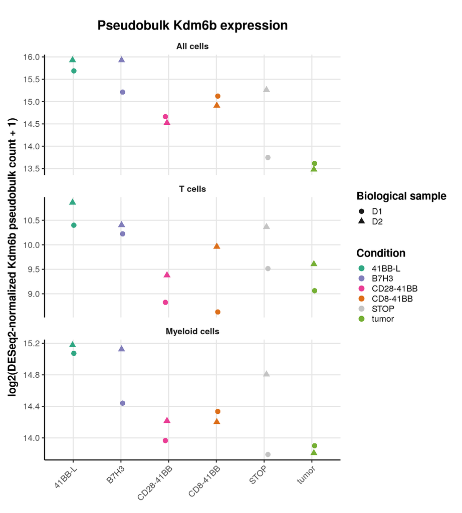

```r
p_pseudobulk <- ggplot(
  pseudobulk_sample_table,
  aes(
    x = condition,
    y = log2_kdm6b_deseq2_normalized_count,
    color = condition,
    shape = sample_number
  )
) +
  geom_point(
    position = position_jitter(width = 0.08, height = 0),
    size = 3,
    alpha = 0.9
  ) +
  facet_wrap(~ compartment, scales = "free_y", ncol = 1) +
  scale_color_manual(values = condition_colors, drop = FALSE) +
  theme_Publication() +
  theme(
    panel.background = element_rect(fill = "white", color = NA),
    plot.background = element_rect(fill = "white", color = NA),
    legend.background = element_rect(fill = "white", color = NA),
    legend.key = element_rect(fill = "white", color = NA),
    strip.background = element_rect(fill = "white", color = NA),
    panel.grid.major = element_line(color = "grey90"),
    panel.grid.minor = element_blank(),
    axis.text.x = element_text(angle = 45, hjust = 1),
    legend.position = "right"
  ) +
  labs(
    title = "Pseudobulk Kdm6b expression",
    x = NULL,
    y = "log2(DESeq2-normalized Kdm6b pseudobulk count + 1)",
    color = "Condition",
    shape = "Biological sample"
  )

p_pseudobulk
```

```r
ggsave(
  filename = file.path(
    plot_dir,
    "kdm6b_pseudobulk_expression_by_compartment.pdf"
  ),
  plot = p_pseudobulk,
  width = 9,
  height = 10,
  device = cairo_pdf
)
```

## 2. Visualize Kdm6b expression within the myeloid compartment

The integrated reduction is used only for visualization. `Kdm6b` expression is drawn from the normalized RNA assay.

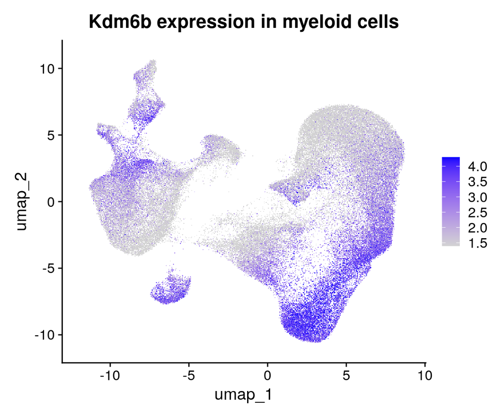

```r
p_kdm6b_feature <- FeaturePlot(
  myeloid_obj,
  features = gene,
  reduction = "umap",
  min.cutoff = "q05",
  max.cutoff = "q95",
  order = TRUE,
  raster = TRUE
) +
  ggtitle("Kdm6b expression in myeloid cells")

p_kdm6b_feature
```

```r
ggsave(
  filename = file.path(plot_dir, "myeloid_kdm6b_featureplot.pdf"),
  plot = p_kdm6b_feature,
  width = 6,
  height = 5,
  device = cairo_pdf
)
```

```r
p_kdm6b_violin <- VlnPlot(
  myeloid_obj,
  features = gene,
  group.by = "seurat_clusters",
  assay = "RNA",
  pt.size = 0
) &
  theme_Publication() &
  theme(
    panel.background = element_rect(fill = "white", color = NA),
    plot.background = element_rect(fill = "white", color = NA),
    legend.background = element_rect(fill = "white", color = NA),
    legend.key = element_rect(fill = "white", color = NA),
    panel.grid.major = element_line(color = "grey90"),
    panel.grid.minor = element_blank()
  ) &
  labs(
    title = "Kdm6b expression by myeloid subcluster",
    x = "Seurat cluster",
    y = "Log-normalized RNA expression"
  )
```

```
## Rasterizing points since number of points exceeds 100,000.
## To disable this behavior set `raster=FALSE`
```

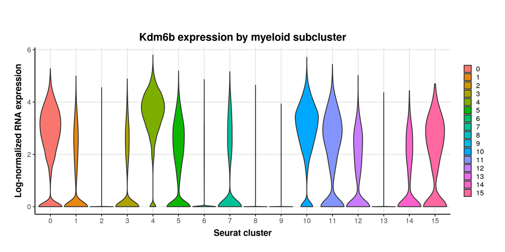

```r
p_kdm6b_violin
```

```r
ggsave(
  filename = file.path(plot_dir, "myeloid_kdm6b_violin_by_subcluster.pdf"),
  plot = p_kdm6b_violin,
  width = 12,
  height = 6,
  device = cairo_pdf
)
```

## 3. Define Kdm6b-high and Kdm6b-low myeloid subclusters

For each qualifying sample/subcluster profile, calculate mean log-normalized Kdm6b expression. Rank subclusters by the median across samples, using detection fraction only to break ties.

```r
kdm6b_sample_subcluster <- aggregate_kdm6b_by_sample_cluster(
  obj = myeloid_obj,
  condition_levels = condition_levels,
  gene = gene,
  subtype_col = "myeloid_subtype"
)

kdm6b_subcluster_ranking <- rank_kdm6b_subclusters(
  sample_cluster_table = kdm6b_sample_subcluster,
  min_cells_per_profile = min_cells_per_profile,
  tail_fraction = tail_fraction,
  subtype_col = "myeloid_subtype"
)

readr::write_tsv(
  kdm6b_subcluster_ranking,
  file.path(results_dir, "myeloid_kdm6b_subcluster_ranking_and_groups.tsv")
)
```

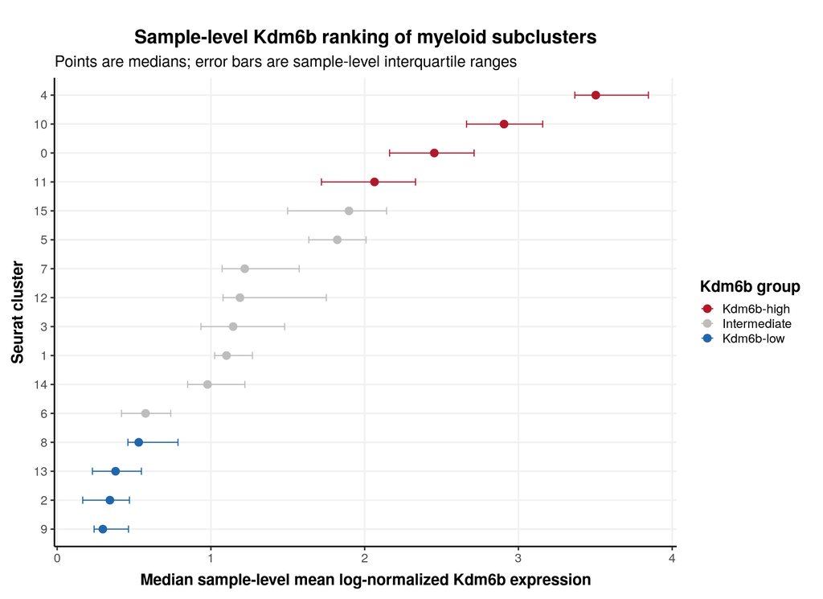

```r
group_colors <- c(
  "Kdm6b-high" = "#B2182B",
  "Intermediate" = "#BDBDBD",
  "Kdm6b-low" = "#2166AC"
)

ranking_plot_data <- kdm6b_subcluster_ranking %>%
  dplyr::mutate(
    kdm6b_group = factor(
      kdm6b_group,
      levels = c(
        "Kdm6b-high",
        "Intermediate",
        "Kdm6b-low"
      )
    )
  ) %>%
  dplyr::arrange(
    kdm6b_group,
    kdm6b_rank,
    as.integer(subcluster)
  ) %>%
  dplyr::mutate(
    seurat_cluster = factor(
      subcluster,
      levels = rev(unique(as.character(subcluster)))
    )
  )

p_ranking <- ggplot(
  ranking_plot_data,
  aes(
    x = seurat_cluster,
    y = median_log_expression,
    color = kdm6b_group
  )
) +
  geom_errorbar(
    aes(
      ymin = q25_log_expression,
      ymax = q75_log_expression
    ),
    width = 0.25,
    linewidth = 0.5
  ) +
  geom_point(size = 3) +
  scale_x_discrete(drop = FALSE) +
  coord_flip() +
  scale_color_manual(values = group_colors, drop = FALSE) +
  theme_Publication() +
  theme(
    panel.background = element_rect(fill = "white", color = NA),
    plot.background = element_rect(fill = "white", color = NA),
    legend.key = element_rect(fill = "white", color = NA),
    legend.position = "right"
  ) +
  labs(
    title = "Sample-level Kdm6b ranking of myeloid subclusters",
    subtitle = "Points are medians; error bars are sample-level interquartile ranges",
    x = "Seurat cluster",
    y = "Median sample-level mean log-normalized Kdm6b expression",
    color = "Kdm6b group"
  )

p_ranking
```

```r
ggsave(
  filename = file.path(plot_dir, "myeloid_kdm6b_subcluster_ranking.pdf"),
  plot = p_ranking,
  width = 11,
  height = 8,
  device = cairo_pdf,
  bg = "white"
)
```

## 4. Visualize Kdm6b expression within the T cell compartment

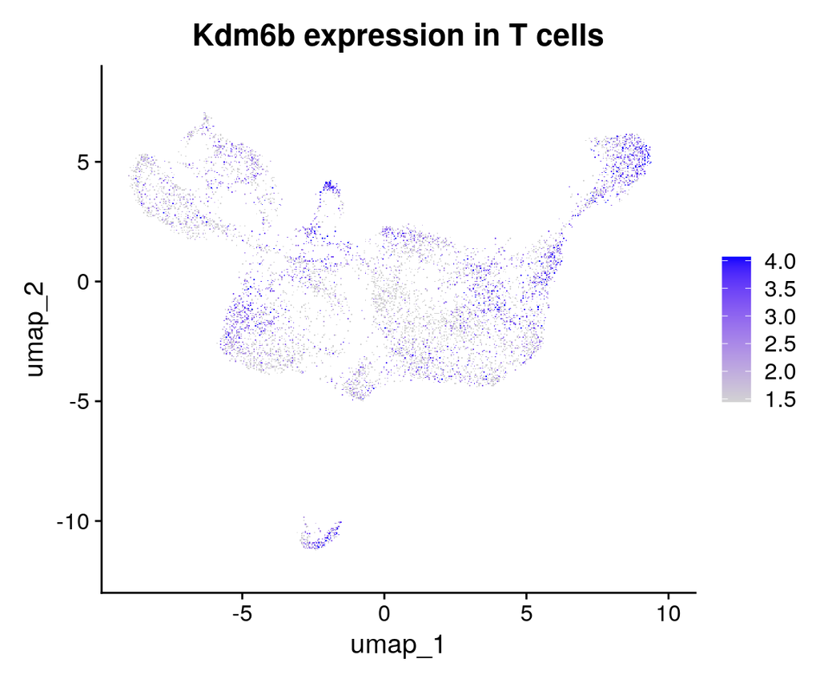

```r
tcell_results_dir <- file.path(analysis_dir, "results", "tcell", "kdm6b")
tcell_plot_dir <- file.path(analysis_dir, "plots", "tcell", "kdm6b")
dir.create(tcell_results_dir, recursive = TRUE, showWarnings = FALSE)
dir.create(tcell_plot_dir, recursive = TRUE, showWarnings = FALSE)

p_tcell_kdm6b_feature <- FeaturePlot(
  tcell_obj,
  features = gene,
  reduction = "umap",
  min.cutoff = "q05",
  max.cutoff = "q95",
  order = TRUE,
  raster = TRUE
) +
  ggtitle("Kdm6b expression in T cells")

p_tcell_kdm6b_feature
```

```r
ggsave(
  filename = file.path(tcell_plot_dir, "tcell_kdm6b_featureplot.pdf"),
  plot = p_tcell_kdm6b_feature,
  width = 6,
  height = 5,
  device = cairo_pdf)
```

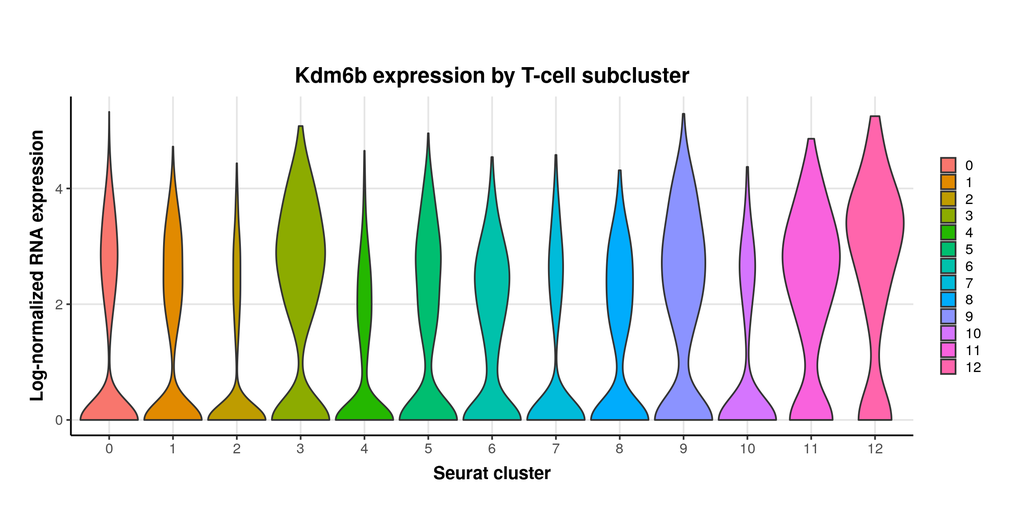

```r
p_tcell_kdm6b_violin <- VlnPlot(
  tcell_obj,
  features = gene,
  group.by = "seurat_clusters",
  assay = "RNA",
  pt.size = 0
) &
  theme_Publication() &
  theme(
    panel.background = element_rect(fill = "white", color = NA),
    plot.background = element_rect(fill = "white", color = NA),
    legend.background = element_rect(fill = "white", color = NA),
    legend.key = element_rect(fill = "white", color = NA),
    panel.grid.major = element_line(color = "grey90"),
    panel.grid.minor = element_blank()
  ) &
  labs(
    title = "Kdm6b expression by T-cell subcluster",
    x = "Seurat cluster",
    y = "Log-normalized RNA expression"
  )

p_tcell_kdm6b_violin
```

```r
ggsave(
  filename = file.path(tcell_plot_dir, "tcell_kdm6b_violin_by_subcluster.pdf"),
  plot = p_tcell_kdm6b_violin,
  width = 12,
  height = 6,
  device = cairo_pdf)
```

## 5. Define Kdm6b-high and Kdm6b-low tcell subclusters

```r
tcell_sample_subcluster <- aggregate_kdm6b_by_sample_cluster(
  obj = tcell_obj,
  condition_levels = condition_levels,
  gene = gene,
  subtype_col = "tcell_subtype"
)

tcell_subcluster_ranking <- rank_kdm6b_subclusters(
  sample_cluster_table = tcell_sample_subcluster,
  min_cells_per_profile = min_cells_per_profile,
  tail_fraction = tail_fraction,
  subtype_col = "tcell_subtype"
)

readr::write_tsv(
  tcell_subcluster_ranking,
  file.path(tcell_results_dir, "tcell_kdm6b_subcluster_ranking_and_groups.tsv")
)
```

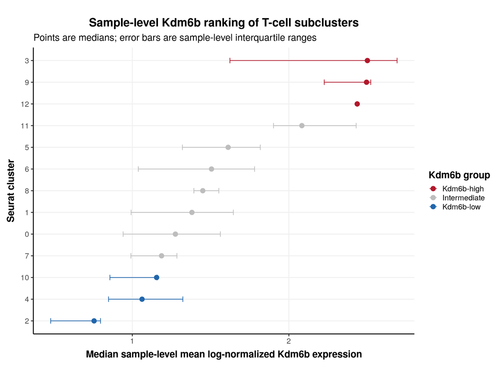

```r
tcell_ranking_plot_data <- tcell_subcluster_ranking %>%
  dplyr::mutate(
    kdm6b_group = factor(
      kdm6b_group,
      levels = c(
        "Kdm6b-high",
        "Intermediate",
        "Kdm6b-low"
      )
    )
  ) %>%
  dplyr::arrange(
    kdm6b_group,
    kdm6b_rank,
    as.integer(subcluster)
  ) %>%
  dplyr::mutate(
    seurat_cluster = factor(
      subcluster,
      levels = rev(unique(as.character(subcluster)))
    )
  )

p_tcell_ranking <- ggplot(
  tcell_ranking_plot_data,
  aes(
    x = seurat_cluster,
    y = median_log_expression,
    color = kdm6b_group
  )
) +
  geom_errorbar(
    aes(
      ymin = q25_log_expression,
      ymax = q75_log_expression
    ),
    width = 0.25,
    linewidth = 0.5
  ) +
  geom_point(size = 3) +
  scale_x_discrete(drop = FALSE) +
  coord_flip() +
  scale_color_manual(values = group_colors, drop = FALSE) +
  theme_Publication() +
  theme(
    panel.background = element_rect(fill = "white", color = NA),
    plot.background = element_rect(fill = "white", color = NA),
    legend.key = element_rect(fill = "white", color = NA),
    legend.position = "right"
  ) +
  labs(
    title = "Sample-level Kdm6b ranking of T-cell subclusters",
    subtitle = "Points are medians; error bars are sample-level interquartile ranges",
    x = "Seurat cluster",
    y = "Median sample-level mean log-normalized Kdm6b expression",
    color = "Kdm6b group"
  )

p_tcell_ranking
```

```r
ggsave(
  filename = file.path(tcell_plot_dir, "tcell_kdm6b_subcluster_ranking.pdf"),
  plot = p_tcell_ranking,
  width = 11,
  height = 8,
  device = cairo_pdf,
  bg = "white"
)
```